# Assignment 8-1 Maximum Likelihood Lab

Feng-Hsun Chang

2016 Dec. 06

# Exercise 1

- What does the shape of the likelihood surface tell us about the identifiability of the parameters? What does it say about which aspects of the data are most informative?

The following is the likelihood contour of the original model with the `logit` function describing the hazard function and the `logit` function depends linearly on the carapath length ($L_i$), i.e. $\mathrm{logit}(p_i) = a + b\,L_i,$.

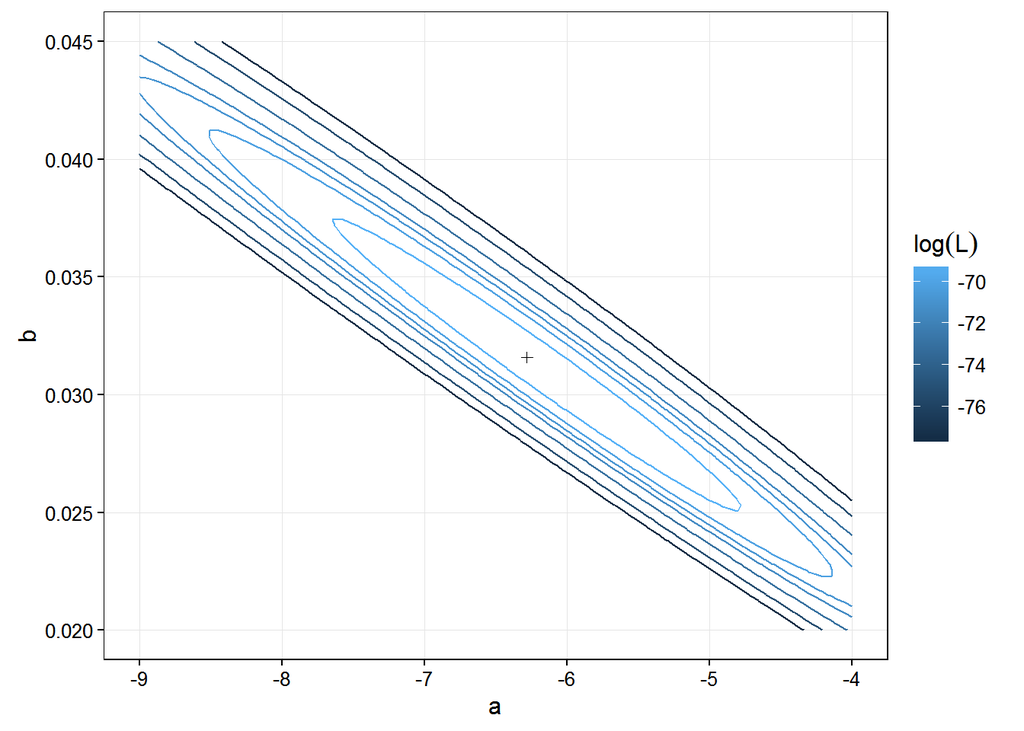

I then add a line to indicates the carapace length at which the probability of seropositive is 50% given the estimated parameter “a” and “b”.

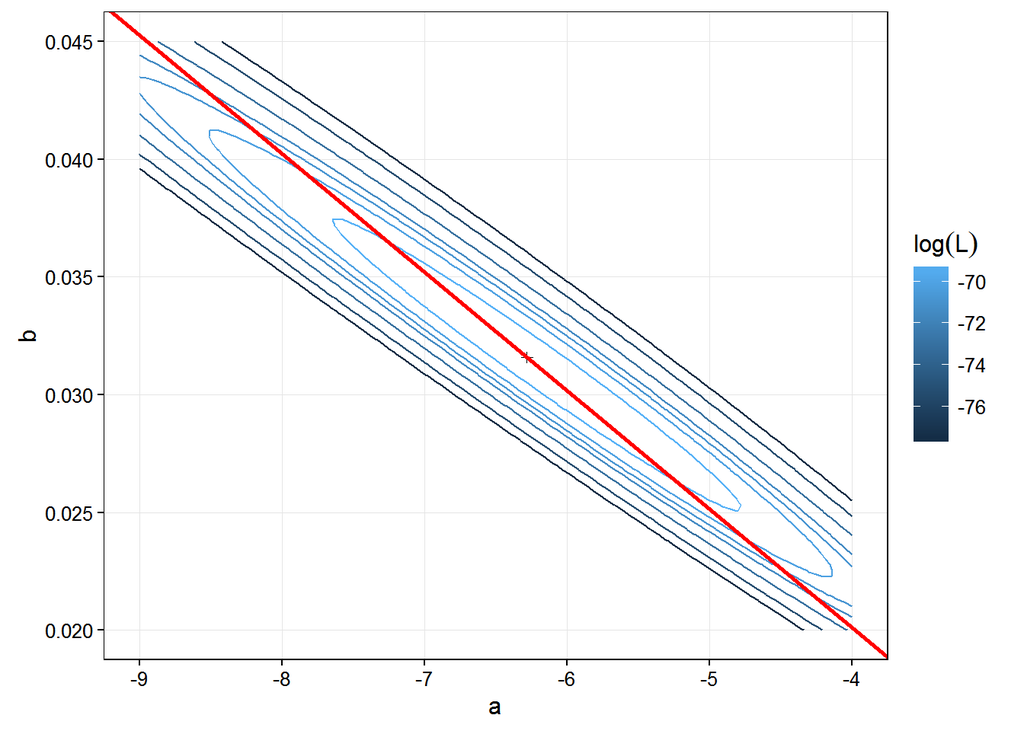

This shape indicates that on a certain axis of parameter “a” and “b” combination, the likelihood of observing this given data are fairly similar. Along this combination axis, the data are not informative to tell if the model is good enough to describe (or explain?) the data.

I now try another model to describe the data with another model that intends to describe how much the probability of seropositive would change when an individual grows larger (or is smaller) than a certain carapace length. This carapace length is the length where the probability of seropositive is 50% given the estimated parameter “a (-6.2817)” and “b (0.0316)” in the previous model. So the odds ration function becomes the following.

$$\mathrm{logit}(p_i) = p_0 + p_1(L_i-198.844)$$
,

where $p_0$ is the probability of seropositive when the carapace length is at 198.844, and $p_1$ is the change of seropositive probability when the individual grows larger (or is smaller) then 198.844.

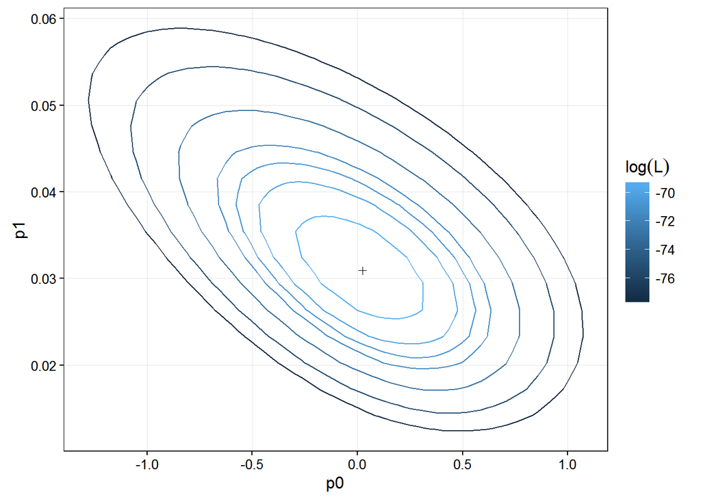

```r
L50 = -(coef(fit)["a"]/coef(fit)["b"])

loglik = function (p, serostatus) {
  sum(log(dbinom(x=serostatus,size=1,prob=p)))
}

nll.1 = function (p0, p1, carapace.length, serostatus) {
  -loglik(p=plogis(p0+p1*(carapace.length-L50)), serostatus)
}

fit.1 = mle2(nll.1, start=list(p0=0,p1=0),data=gt1)

params.1 =
  expand.grid(
  p0=seq(coef(fit.1)["p0"]-1.5, coef(fit.1)["p0"]+1.5, length=100),
  p1=seq(coef(fit.1)["p1"]-0.15, coef(fit.1)["p1"]+0.15, length=100)) %>%
  ddply(~p0+p1, mutate,
        loglik=-nll.1(p0, p1, gt1$carapace.length, gt1$serostatus)
  )

breaks.1 = logLik(fit.1)-qchisq(p=c(0.5,0.8,0.9,0.95,0.99,0.999,0.9999),df=2)/2

ggplot(data=params.1, aes(x=p0, y=p1, z=loglik))+
  geom_contour(aes(color=..level..), breaks=breaks.1)+
  geom_point(x=coef(fit.1)["p0"], y=coef(fit.1)["p1"], shape=3)+
  labs(color=expression(log(L)))+
  theme_bw()+
  theme(#panel.grid.major=element_blank(),
        panel.grid.minor=element_blank(),
        strip.background = element_blank(),
        panel.border=element_rect(color="black"),
        legend.key = element_blank())
```

# Exercise 2

- Use `mle2` to fit the survival curve, assuming a constant force of infection and that $L \propto a$. Estimate the force of infection. What are its units? Use confidence intervals (CI) to quantify the uncertainty in your estimate. Make a plot that overlays the model predictions on the data. Plot the likelihood curve. Indicate the MLE and CI for different levels on your plot.

Here I’m using the following exponential function to model the increase of seropositive probability with carapace length.

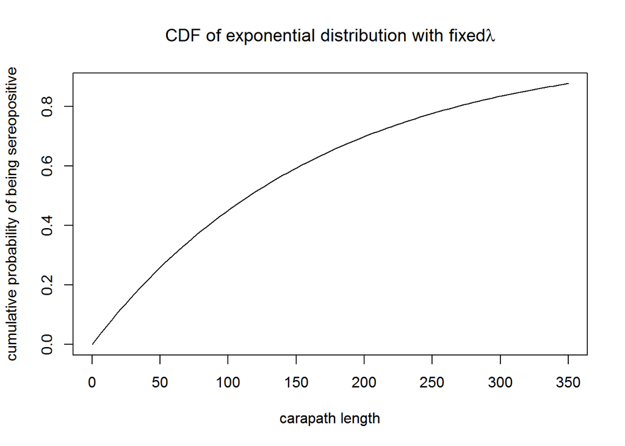

```r
curve(1-exp(-(x*0.006)),from=0,to=350,
      xlab="carapath length",
      ylab="cumulative probability of being sereopositive",
      main=expression(paste("CDF of exponential distribution with fixed", lambda)))
```

Now I estimate the $\lambda$ parameter that determines, at given carapace length, the probability of seropositive and the maximum likelihood associated with the estimated $\lambda$.

```r
nll.2 = function (lam, carapace.length, serostatus) {
  -sum(log(dbinom(x=serostatus, size=1, prob=1-exp(-(carapace.length*lam)))))
}

fit.2 = mle2(nll.2, start=list(lam=0.005),data=gt1)

coef(fit.2)
```

```
##         lam
## 0.005704184
```

```r
logLik(fit.2)
```

```
## 'log Lik.' -82.61491 (df=1)
```

- Note that I mute the warning here as I know some negative $\lambda$ would produce probabilities that generate NaN when being used to calculate likelihood.

The $\lambda$ is estimated to be 0.0057042 and the associated maximum likelihood is -82.6149113.  
I then calculate the confidence interval of the $\lambda$ parameter.

```
##       2.5 %      97.5 %
## 0.004589098 0.006881101
```

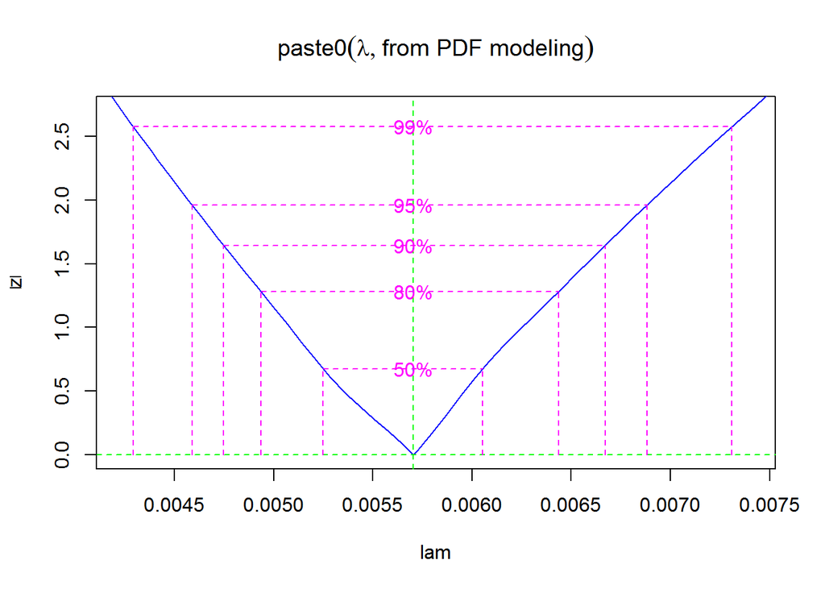

I then overlay the model predictions (blue line) with 95% confidence interval on the data.

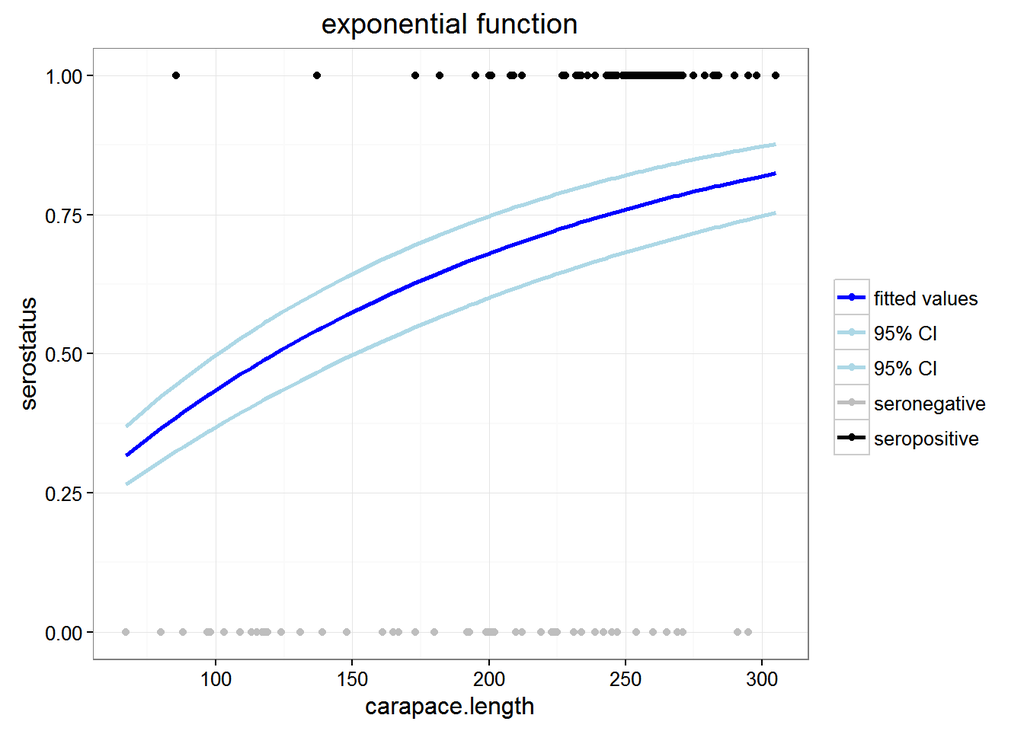

```r
gt1 =
  gt1 %>% mutate(
    fitted.exp=with(as.list(coef(fit.2)),pexp(carapace.length, rate=lam)),
    fitted.low=with(as.list(coef(fit.2)),pexp(carapace.length, rate=confint(fit.2)[1])),
    fitted.hi=with(as.list(coef(fit.2)),pexp(carapace.length, rate=confint(fit.2)[2])))

gt1 %>%
  ggplot(aes(x=carapace.length))+
  geom_point(aes(y=serostatus, color=elisa))+
  geom_line(aes(y=fitted.exp, color="fitted"), size=1)+
  geom_line(aes(y=fitted.low, color="low"), size=1)+
  geom_line(aes(y=fitted.hi, color="hi"), size=1)+
  scale_color_manual(name="",
                     values=c(fitted="blue", neg="grey", pos="black", low="light blue", hi="light blue"),
                     labels=c(fitted="fitted values", neg="seronegative", pos="seropositive", low="95% CI", hi="95% CI"))+
  ggtitle("exponential function")
```

From this plot we see that the fitted probability of seropositive increases with carapace length. The increasing rate, $\lambda$, is estimated to be 0.0057042. The $\lambda$ is the exponential decreasing rate of the probability of seronegative. The unit of $\lambda$ is $mm^{-1}$.

# Exercise 3

- Investigate a two-parameter model in which the hazard increases with age.

Here I make the infection hazard a function of carapace length. I first try the hazard function in the Michaelis-Menten form.

$$\lambda(L) = \frac{r_m\,L}{K+L}$$
,

Accordingly, the CDF the determines the probability of an individual to be seropositive is

$${\mathbb{P}\left[{X_i=\text{pos}}\right]} = 1 - \exp{\left[-\int_0^L\!\lambda(L){\mathrm{d}{L}}\right]} = 1 - \exp{\left[-r_m\,K (\frac{L}{K} - Log(1 + \frac{L}{K}) \right ]}$$
.

The CDF of the sereopositive probability function is the following.

```r
loglik = function (p, serostatus) {
  sum(log(dbinom(x=serostatus,size=1,prob=p)))
}

nll.3 = function (rm, K, carapace.length, serostatus) {
  -loglik(p= 1 - exp(-rm*K*(carapace.length/K - log(1+(carapace.length/K)))), serostatus)
  #if (!is.finite(ll)) print(c(rm,K,ll))
  #ll
}

fit.3 = mle2(nll.3, start=list(rm=0.1, K=10),data=gt1, trace=TRUE)

coef(fit.3)
```

```
##           rm            K
##   0.01292809 116.33333734
```

```r
logLik(fit.3)
```

```
## 'log Lik.' -77.15495 (df=2)
```

- Note that, similar to previous model (the model with constant hazard), there are some negative $\lambda$ would produce probabilities that generate NaN when being used to calculate likelihood.

The estimated maximum decreasing rate of the probability of seropositive ($r_m$) is 0.0129 and the carapace length ($K$) that would render half of the maximum decreasing rate is about 116.3333mm. The associated maximum likelihood is -77.1549452. The CDF with estimated $r_m$ and $K$ is as follow.

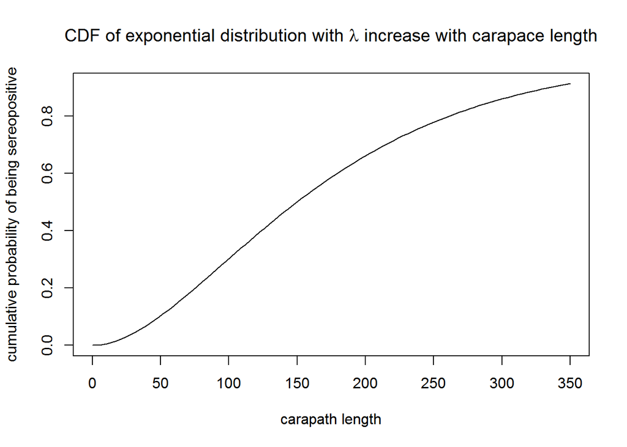

```r
cdf = function(x, rm, K){
  1-exp(-(rm*K*(x/K - log(1+(x/K)))))
}
curve(cdf(x, coef(fit.3)["rm"], coef(fit.3)["K"]),from=0,to=350,
      xlab="carapath length",
      ylab="cumulative probability of being sereopositive",
      main=expression(paste("CDF of exponential distribution with ", lambda, " increase with carapace length")))
```

I now construct the likelihood contour.

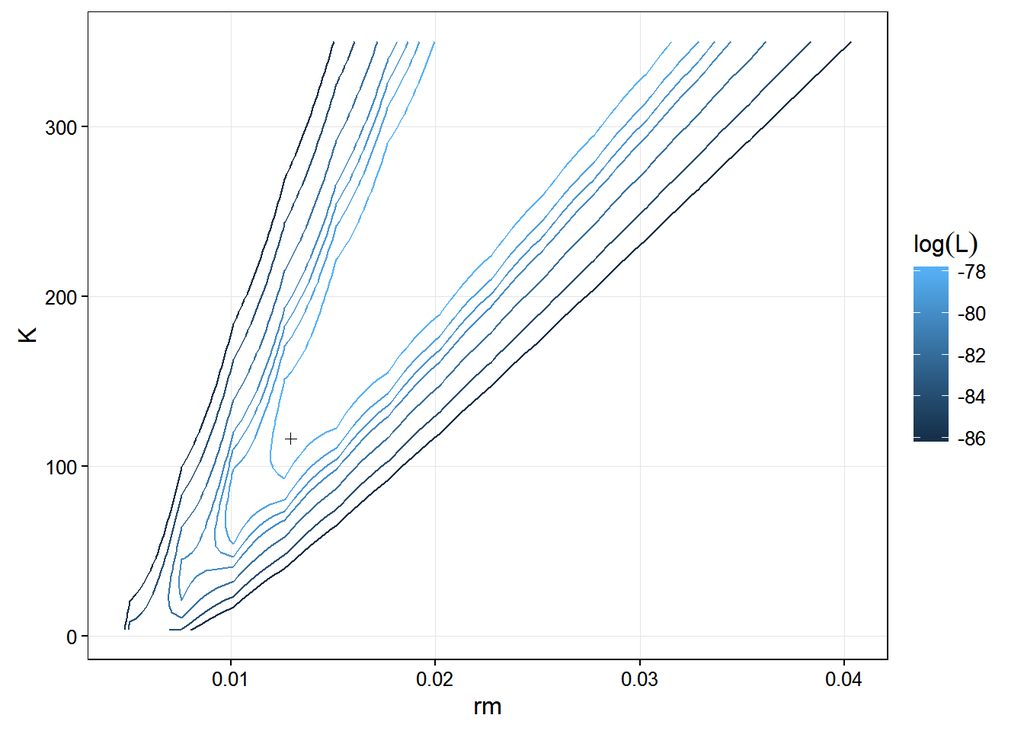

```r
params.3 =
  expand.grid(
  rm=seq(0, 0.25, length=100),
  K=seq(0, 350, length=100)) %>%
  ddply(~rm+K, mutate,
        loglik=-nll.3(rm, K, gt1$carapace.length, gt1$serostatus)
  )

breaks.3 = logLik(fit.3)-qchisq(p=c(0.5,0.8,0.9,0.95,0.99,0.999,0.9999),df=2)/2

ggplot(data=params.3, aes(x=rm, y=K, z=loglik))+
  geom_contour(aes(color=..level..), breaks=breaks.3)+
  geom_point(x=coef(fit.3)["rm"], y=coef(fit.3)["K"], shape=3)+
  labs(color=expression(log(L)))+
  theme_bw()+
  theme(#panel.grid.major=element_blank(),
        panel.grid.minor=element_blank(),
        strip.background = element_blank(),
        panel.border=element_rect(color="black"),
        legend.key = element_blank())
```

I found that this model is rather non-informative again as there is a large area where the combinations of $r_m$ and $K$ would have similar likelihood.

Here I overlay the fitted seropositive probability to the data.

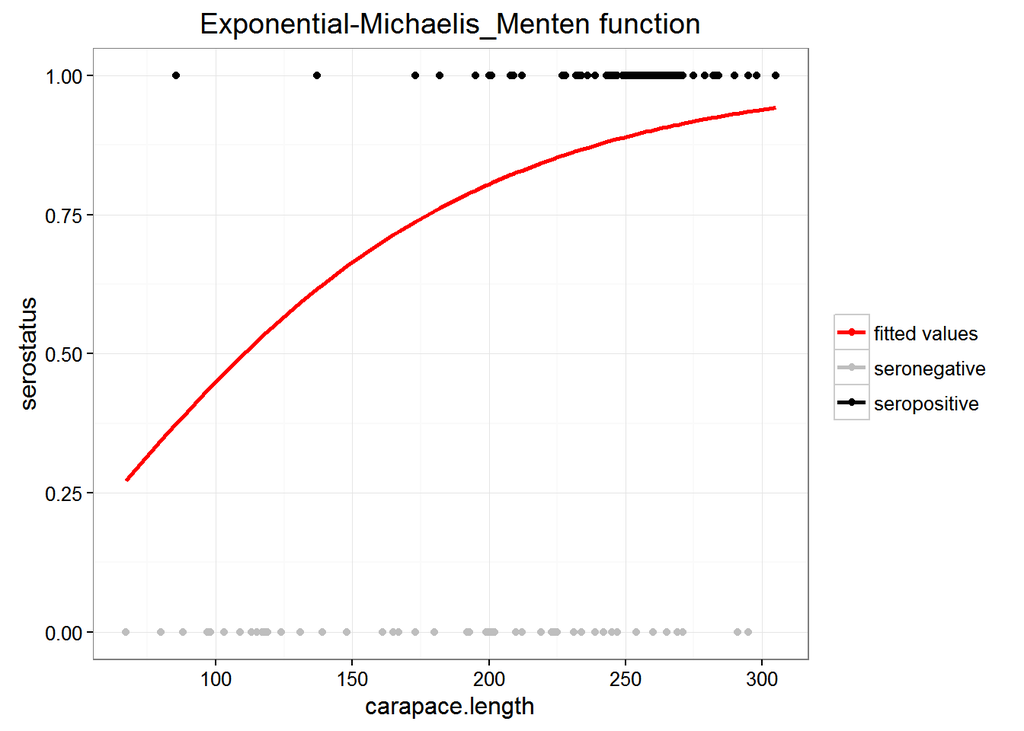

```r
gt1 =
  gt1 %>% mutate(
    fitted.MM=with(as.list(coef(fit.3)),pexp(carapace.length, rate=rm*(carapace.length/(K+carapace.length)))))

gt1 %>%
  ggplot(aes(x=carapace.length))+
  geom_point(aes(y=serostatus, color=elisa))+
  geom_line(aes(y=fitted.MM, color="fitted"), size=1)+
  scale_color_manual(name="",
                     values=c(fitted="red", neg="grey", pos="black"),
                     labels=c(fitted="fitted values", neg="seronegative", pos="seropositive"))+
  ggtitle("Exponential-Michaelis_Menten function")
```

The above model has clear mechanism that describe the behavior of each individual but it is not informative in terms of the fitted parameters.

Here I model the CDF of sereopositive probability directly with the Michaelis-Menten function. However, this is rather not mechanistic as it does not clearly describe the bahavior of each individual (i.e. how the probability of sereopositive increase with carapath length).  
I then use the `optim` function to find the two parameters in the Michaelis-Menten function that lead to the maximum likelihood. These two parameters are the maximum probability ($p.max$) for an individual to be sereopositive and the carapace length that renders 50% of possibility of seropositive ($Km$).

Note that I constrain the $p.max$ to be from 0 to 1. Otherwise it is not biologically feasible.

```r
loglik = function (p, serostatus) {
  sum(log(dbinom(x=serostatus,size=1,prob=p)))
}

nll.4 = function (data, par) {
  with(data, -loglik(p=par[1]*(data[,"carapace.length"]/(par[2]+data[,"carapace.length"])), data[,"serostatus"]))
}

fit.4 = optim(par=c(0.1, 50), nll.4, method="L-BFGS-B", lower=c(0,0), upper=c(1,max(gt1[,"carapace.length"])), data=gt1, hessian=TRUE)

p.max=fit.4$par[1]
Km=fit.4$par[2]
ML=-fit.4$value
```

The max probability of seropositive ($p.max$) is 1 and the carapace length that would render 50% of possibility of seropositive ($Km$) is about 97.535mm. The associated maximum likelihood is -88.0226788. It is not surprising that the “p.max” parameter is 1 as there is always individuals that are sereopositive. However, I found it intriguing that the carapace length that renders 50% of probability of seropositive is about half of that in the first model (198.843991). This suggests to me that the fundamental differences between the model can results in different estimates, although the biological interpretations are similar.

Now I construct the likelihood surface of the two parameters.

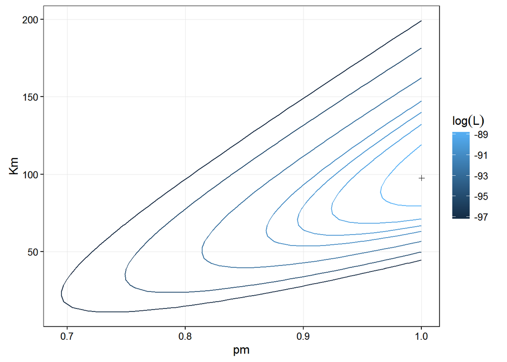

```r
params.4 =
  expand.grid(
  pm=seq(0, 1, length=100),
  Km=seq(0, 350, length=100)) %>%
  ddply(~pm+Km, mutate,
        loglik=-nll.4(data=gt1, par=c(pm, Km))
  )

breaks.4 <- -fit.4$value-qchisq(p=c(0.5,0.8,0.9,0.95,0.99,0.999,0.9999),df=2)/2

ggplot(data=params.4, aes(x=pm, y=Km, z=loglik))+
  geom_contour(aes(color=..level..), breaks=breaks.4)+
  geom_point(x=fit.4$par[1], y=fit.4$par[2], shape=3)+
  labs(color=expression(log(L)))+
  theme_bw()+
  theme(#panel.grid.major=element_blank(),
        panel.grid.minor=element_blank(),
        strip.background = element_blank(),
        panel.border=element_rect(color="black"),
        legend.key = element_blank())
```

From the figure, we see that both parameters are informative with confidence interval of $p.max$ parameter ranges from about 0.96 to 1 and $Km$ parameter ranges from about 80 to 110.

Given this likelihood contour, I now calculate the 95% confidence interval for each of the two parameters. The step by step description of my method is written in the comment.

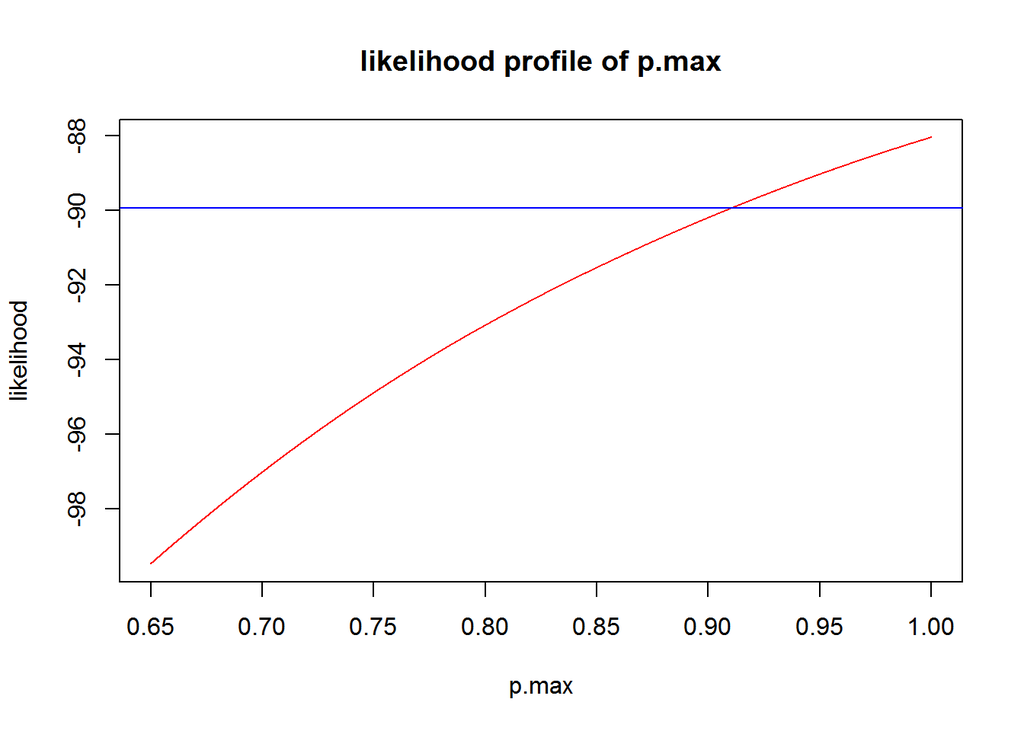

```r
# I write a crude function to calculate the highest likelihood at given p.max value (i.e. the maximum likelihood at given p.max)
highlike = function(p){

  highli = -nll.4(data=gt1, par=c(p, 0))
  for (i in seq(from=0, to=350, by=0.1)){
    like = -nll.4(data=gt1, par=c(p, i))
    if (like>highli){highli=like
    }else{highli=highli}
  }
  return(highli)
}

# I then vary p.max from 0.65 to 1 and calculate the largest likelihood at given p.max value.
p = seq(from=0.65, to=1, by=0.01)
pm.like = sapply(p, highlike, simplify="array")
pm.like.l = as.data.frame(cbind(pm.like, p))

# I then ues the loess function to derive the smooth function of likelihood~p in a very fine scale.
pm.lo = loess(pm.like~p, data=pm.like.l)
pm.fit = cbind(predict(pm.lo, newdata=data.frame(p=seq(min(p), max(p), 0.00001)), se=TRUE)$fit,
               seq(min(p), max(p), by=0.00001))

plot(pm.like~p, data=pm.like.l, xlab="p.max", ylab="likelihood", main="likelihood profile of p.max", type="n")
lines(pm.fit[,1]~pm.fit[,2], col="red")
abline(h= ML-qchisq(0.95, df=1)/2, col="blue")
```

Here I plot the likelihood profile of $p.max$. The red line indicates the likelihood profile and the blue line indicates the likehood value below which the model parameter value would have low enough probability (5%) to produce the observed data when comparing to the model parameter value with maximum likelihood.

```r
# I use the chisquare distribution to calculate the limit of likelihood below which the model parameter value would have low enough probability (5%) to produce the observed data when comparing to the model parameter value with maximum likelihood.
like.lim = ML-qchisq(0.95, df=1)/2

# I calculate the difference between predicted likelihood (from loess function) and the likelihood limit.
pm.fit = cbind(pm.fit, pm.fit[,1]-like.lim)

# I find the parameter value that is closet to the model parameter value that produce the likelihood limit.
p.max.CI = pm.fit[which(abs(pm.fit[,3])==min(abs(pm.fit[,3]))),2]
```

I constrain the range of $p.max$ from 0 to 1, so that the 95% confidence interval of $p.max$ is 0.91002 to 1.

I now construct the 95% confidence interval and likelihood profile for $Km$ in a same fashion.

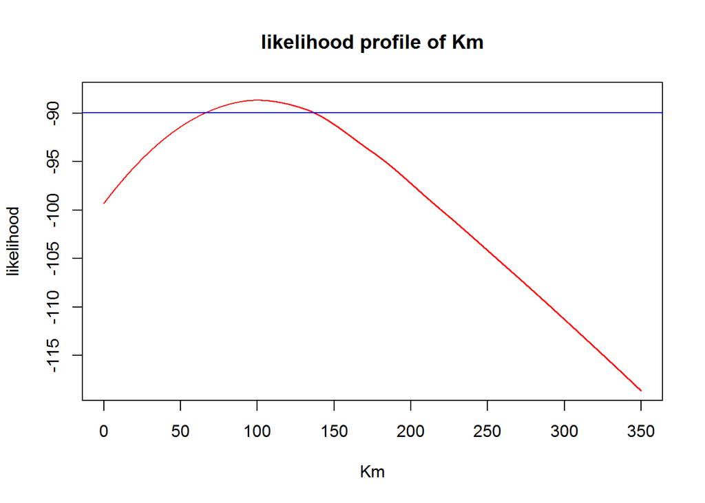

```r
# I write a crude function to calculate the highest likelihood at given p.max value (i.e. the maximum likelihood at given p.max)
highlike = function(k){

  highli = -nll.4(data=gt1, par=c(0, k))
  for (i in seq(from=0.65, to=1, by=0.01)){
    like = -nll.4(data=gt1, par=c(i, k))
    if (like>highli){highli=like
    }else{highli=highli}
  }
  return(highli)
}

# I then vary p.max from 0.65 to 1 and calculate the largest likelihood at given p.max value.
K = seq(from=0, to=350, by=0.1)
K.like = sapply(K, highlike, simplify="array")
K.like.l = as.data.frame(cbind(K.like, K))

# I then ues the loess function to derive the smooth function of likelihood~p in a very fine scale.
K.lo = loess(K.like~K, data=K.like.l)
K.fit = cbind(predict(K.lo, newdata=data.frame(K=seq(min(K), max(K), 0.01)), se=TRUE)$fit,
               seq(min(K), max(K), by=0.01))

plot(K.like~K, data=K.like.l, xlab="Km", ylab="likelihood", main="likelihood profile of Km", type="n")
lines(K.fit[,1]~K.fit[,2], col="red")
abline(h= ML-qchisq(0.95, df=1)/2, col="blue")
```

Here I plot the likelihood profile of the $Km$ parameter. The red line is the likelihood profile and the blue line is the likelihood limit.

```r
# I use the chisquare distribution to calculate the limit of likelihood below which the model parameter value would have low enough probability (5%) to produce the observed data when comparing to the model parameter value with maximum likelihood.
like.lim = ML-qchisq(0.95, df=1)/2

# I calculate the difference between predicted likelihood (from loess function) and the likelihood limit.
K.fit = as.data.frame(cbind(K.fit, K.fit[,1]-like.lim))

# I multiply the two nearby likelihood values to find where the likelihood limit corss the likelihood profile. The negative product indicates where the likelihood cross the likelihood profile.
prod=c()
for (i in 1: (nrow(K.fit)-1)){
  prod = c(prod, K.fit[i,"V3"]*K.fit[i+1,"V3"])
}

# The lower confidence interval is the first negative product and the higher confidence interval is the second negative product.
K.CI.low = (K.fit[which(prod<0)[1],2] + K.fit[which(prod<0)[1]+1,2])/2
K.CI.high = (K.fit[which(prod<0)[2],2] + K.fit[which(prod<0)[2]+1,2])/2
```

The confidence interval of $Km$ parameter is 66.355 to 136.785.

Now I overlay the fitted probability onto the data.

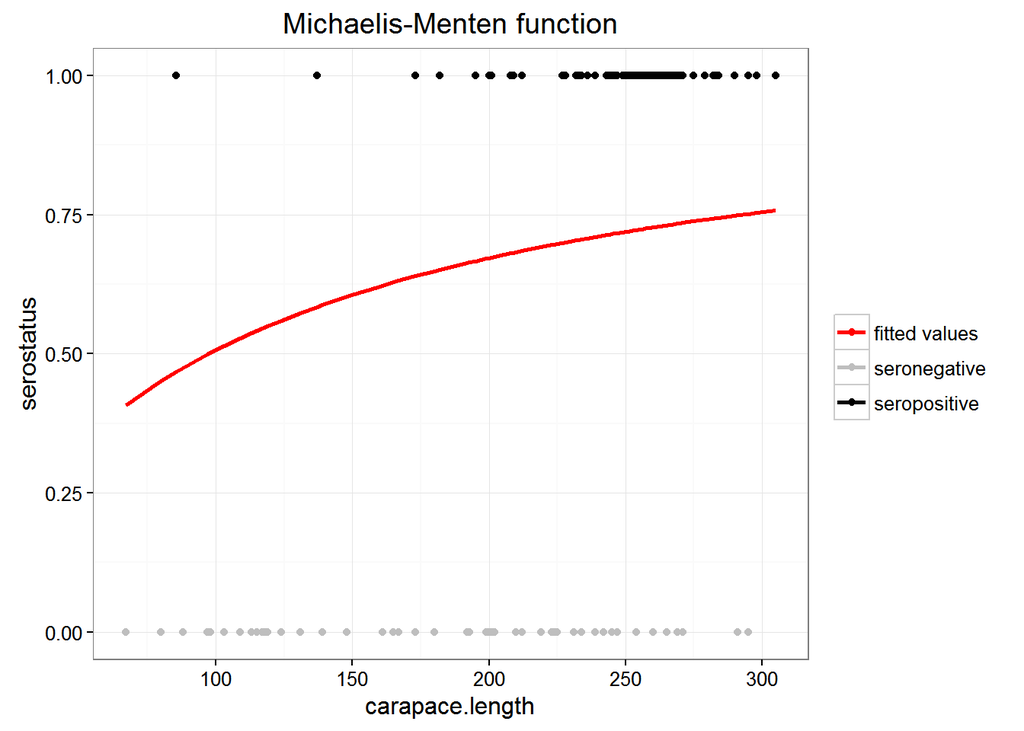

```r
gt1 =
  gt1 %>% mutate(
    fitted.MM=fit.4$par[1]*(gt1[,"carapace.length"]/(fit.4$par[2]+gt1[,"carapace.length"])))

gt1 %>%
  ggplot(aes(x=carapace.length))+
  geom_point(aes(y=serostatus, color=elisa))+
  geom_line(aes(y=fitted.MM, color="fitted"), size=1)+
  scale_color_manual(name="",
                     values=c(fitted="red", neg="grey", pos="black"),
                     labels=c(fitted="fitted values", neg="seronegative", pos="seropositive"))+
  ggtitle("Michaelis-Menten function")
```

The fitted probability of this model is the one with lowest predicted seropositive probability when at maximum carapace length in the data and the highest predicted seropositive probability when at minimum carapace length in the data.

# Exercise 4

So far, I have fitted 5 models with different functions describing the probability of sereopositive (i.e. one minus the survival function; $p_i$ is the probability of seropositive) to the data .
1.A generic logistic function.
$$\mathrm{logit}(p_i) = a + bL_i$$

2.A modified logistic function.
$$\mathrm{logit}(p_i) = p_0 + p_1(L_i-198.844)$$
,

where $p_0$ is the probability of seropositive when the carapace length is at 198.844, and $p_1$ is the change of seropositive probability when the individual grows larger (or is smaller) then 198.844.

5.Sereopositive probability function per se follows a Mechaelis-Menten function.

$$p_i = p.max\,(\frac{L_i}{Km+L_i})$$
,

where $p.max$ determines the maximum probability of seropositive and $Km$ determines the carapace length that renders half of the maximum seropositive probability.

Now I campare the AIC value of these 5 models, since none of these models are nested.

```r
AICtable=data.frame()

for (i in 1:5){
  AICtable[i,1] = paste0("Model", i)
}

AICtable[1,2] = round(AIC(fit),3)
AICtable[2,2] = round(AIC(fit.1),3)
AICtable[3,2] = round(AIC(fit.2),3)
AICtable[4,2] = round(AIC(fit.3),3)
AICtable[5,2] = round(2*fit.4$value+2*length(fit.4$par),3)
  colnames(AICtable)=c("Model", "AIC value")

kable(AICtable)
```

| Model | AIC value |
| --- | --- |
| Model1 | 140.875 |
| Model2 | 140.858 |
| Model3 | 167.230 |
| Model4 | 158.310 |
| Model5 | 180.045 |

```r
AIC(fit, fit.1)
```

```
##        AIC df
## 1 140.8752  2
## 2 140.8578  2
```

From the above table, I see that model 1 and 2 (the generic logistic link function) performs the best from the five. However, Model 2 (modified logistic link function) would be the better than Model 1 as the parameters are more informative and easier to interpret. The third model (constant hazard) can be improved when making the hazard increase with carapath length nonlinearly (the model 4), but using exponential function to describe the survival function is not comparable to the models that use logit function. The final model that uses Mechaelis-Menten function to describe the survival function is even worse and does not imply clear mechanism.